# Four Mutations in the SI Gene Are Responsible for the Majori... : Journal of Pediatric Gastroenterology and Nutrition

## METHODS

To evaluate the genetic approach for the confirmatory diagnosis of CSID, we designed a study to obtain DNA samples from patients with a confirmed biopsy diagnosis. Families who volunteered for this study were recruited by 4 mechanisms: a letter to gastroenterologists, booth and literature at gastroenterology meetings, package inserts in Sucraid boxes, and notices on patient listservs by families participating in the study. The most successful mechanism was family contacts from the listserv. The above patient recruitment methods were approved by an institutional review board.

For inclusion in the study, probands had to have had a bowel biopsy with normal histology and normal lactase but a deficiency of sucrase and/or isomaltase, as defined by the testing laboratory. Twenty-seven children were deficient for both sucrase and isomaltase and 4 children were deficient for sucrase but had low normal activity for isomaltase. Biological samples for DNA isolation were obtained through saliva collected in Oragene-DNA self-collection kits (DNA Genotek Inc, Kanata, Canada) <sup>(8)</sup> or blood spotted onto filter paper. DNA from saliva was isolated according to the Oragene-DNA instructions provided from the kit, and DNA from blood spots was isolated using the 5-PRIME DNA isolation kit (ArchivePure DNA Blood Kits, 5-PRIME, Gaithersburg, MD). Primers to amplify 44 amplicons were designed to interrogate all 48 exons and 20 to 40 nucleotides of the flanking introns. The generated amplicons were evaluated for quality by first identifying the appropriate size on a 1% agarose gel and, if satisfactory, by subsequent DNA sequencing by Sanger dideoxy sequencing <sup>(9)</sup> using an ABI Prism 3130xl genetic analyzer (Applied Biosystems, Carlsbad, CA). The subsequent exons and flanking introns were compared to the GenBank number NM_001041.3 to detect nucleotide alterations. Nucleotide numbering used the A of the ATG translation initiation start site as nucleotide +1.

## RESULTS

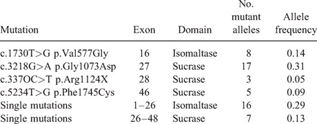

Table 1:

Frequency distribution of *SI* gene mutations

Because patient selection was based on clinical symptoms with documented deficiency of sucrase and/or isomaltase from jejunal biopsies, each of the 4 mutations can be considered to be pathogenic. In addition, 3 of the 4 mutations (p.Val577Gly, p.Gly1073Asp, and p.Phe1745Cys) have been identified and studied previously for their cellular trafficking and have been confirmed to abolish sucrase and isomaltase activity <sup>(10)</sup>. The fourth mutation, p.Arg1124X, introduces a chain termination codon and interrupts the amino acid coding sequence.

Three of the 4 common mutations are in the sucrase domain, with 1 in the isomaltase domain. No mutations in this study were identified in the membrane anchor or stalk region. These 4 mutations account for 59% of the identified changes. The remaining 41% were rare events and are probably “private” mutations restricted to few individuals or families.

If one assumes Hardy-Weinberg equilibrium (p<sup>2</sup> + 2pq + q<sup>2</sup>) for the mutations in this population, there is an 83% probability that an individual of European ethnicity with CSID will have at least 1 of the 4 mutations (2pq + q<sup>2</sup>), where 2pq = 0.48 (1 common mutation) and q<sup>2</sup> = 0.35 (2 common mutations). In 17% of severe cases (p<sup>2</sup>) of CSID, individuals will have 2 rare mutations not detected by a DNA diagnostic panel that assays only for the common 4.

Thus, consideration should be given to the use of genetic testing using saliva or blood for confirmation of CSID as an alternative to sedation, intestinal biopsy, and assay of intestinal enzymes. Such an approach would validate the diagnosis in a majority (83%) of symptomatic children of European ancestry with CSID.

## REFERENCES

1. Treem WR. Congenital sucrase-isomaltase deficiency. *J Pediatr Gastroenterol Nutr* 1995; 21:1–14.

- Cited Here |
- [View Full Text](https://journals.lww.com/jpbs/00005176-199507000-00001.fulltext) | [PubMed](http://www.ncbi.nlm.nih.gov/pubmed/8576798) | [CrossRef](https://doi.org/10.1097%2F00005176-199507000-00001)

2. Sander P, Alfalah M, Keiser M, et al. Novel mutations in the human sucrase-isomaltase gene (SI) that cause congenital carbohydrate malabsorption. *Hum Mutat* 2006; 27:119.

- Cited Here |
- [PubMed](http://www.ncbi.nlm.nih.gov/pubmed/16329100) | [CrossRef](https://doi.org/10.1002%2Fhumu.9392)

3. Peterson M, Herber R. Intestinal sucrase deficiency. *Trans Assoc Am Physicians* 1967; 80:275–283.

4. Welsh J, Poley J, Bhatia M, et al. Intestinal disaccharidase activities in relation to age, race, and mucosal damage. 1978; 75:847–855.

5. Bell R, Draper H, Bergan JG. Sucrose, lactose, and glucose intolerance in northern Alaskan Eskimos. 1973; 26:1185–1190.

6. Ellestad-Sayad J, Haworth J, Hildes J. Disaccharide malabsorption and dietary patterns in two Canadian Eskimo communities. 1978; 31:1473–1478.

7. Keiser M, Alfalah M, Propsting MJ, et al. Altered folding, turnover, and polarized sorting act in concert to define a novel pathomechanism of congenital sucrase-isomaltase deficiency. 2006; 281:14393–14399.

8. Rogers NL, Cole SA, Lan HC, et al. New saliva DNA collection method compared to buccal cell collection techniques for epidemiological studies. 2007; 19:319–326.

9. Slatko BE, Kieleczawa J, Ju J, et al. “First generation” automated DNA sequencing technology. 2011; 96:7.2.1-2.28.

10. Alfalah M, Keiser M, Leeb T, et al. Compound heterozygous mutations affect protein folding and function in patients with congenital sucrase-isomaltase deficiency. 2009; 136:883–892.

Copyright 2012 by ESPGHAN and NASPGHAN

[figure not shown]

- November 2012

[figure not shown]

- November 2012

[figure not shown]

- January 2021

[figure not shown]

- May 2022

[figure not shown]

- July 2017

[figure not shown]

- June 2021